# Author Introduction

Debit and Jae are Students of MS in Data Science and Analytics.

[figure not shown]

## Debit Paudel

Data Scientist

Graduate Research Assistant at GVSU

**Biography**

I write codes in C#, Python , R and .NET Frameworks.Besides that, I’m also familiar with Machine Learning,Image Processing,Deep Learning, SQL and NoSQL databases.

For pleasure, I enjoy books 📖, cooking 🍳, music 🎶, travel ✈.

You might want to read my **Data Science Blogs**.

**Interests**

- Data Science / Machine Learning
- Deep Learning

**Education**

- 🎓 MS Data Science & Analytics , GVSU
- 🎓 B.E. Electronics & Comm., Tribhuvan University

## Skills

#### R Programming

Apply data science with R using tidyverse, automate business reports, build distill website and R shiny app.

#### Data Visualization

Visualize the data using different tools like ggplot2, matplotlib, seaborn etc.

#### Python

Doing Research Project on Deep Learning using Selenium,VADER, nltk,Tensorflow etc. Have Python development experience for Data Science projects.

#### SQL

Have working experience of SQL database like Microsoft SQL Server, MySQL etc.

#### C# and .NET Programming

Have 4 years working experience in C# and .NET Frameworks.

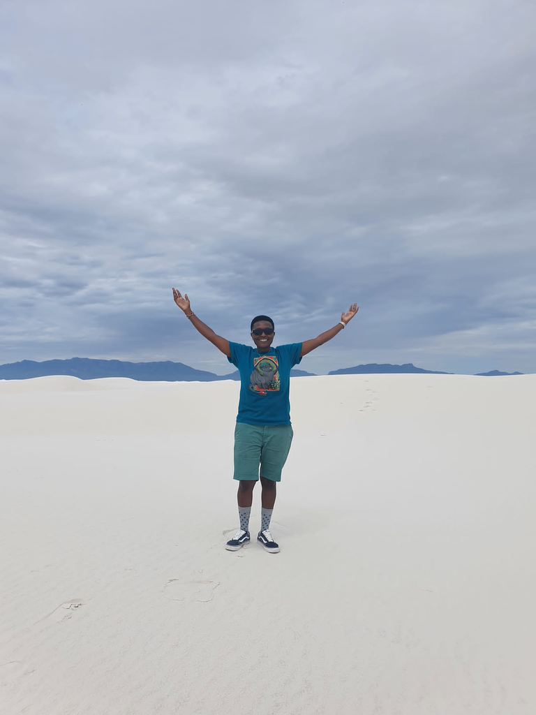

## Jae Mwangi

Data Analyst

Public Health Administrator at GVSU

**Biography**

I enjoy seeing data come to life through visualizations in R Grammar of Graphics. I am also familiar with various database management systems such as SQL, noSQL databases (MongoDB, Redis and Neo4j). I am also practicing my Python skills.

I enjoy reading 📖, outdoors activities, music 🎶, travel ✈.

You might want to read my **Data Science Blogs**.

**Interests**

- Data Analytics

**Education**

- 🎓 MS Data Science & Analytics , GVSU
- 🎓 PGDP Financial Mathematics, University of Exeter

## Skills

#### R Programming

Apply data science with R using tidyverse, automate business reports, build dashboard with R / Shiny.

#### Data Visualization

Visualize the data using different tools like ggplot2, matplotlib, seaborn, tableau, PowerBI etc.

#### Python

Have graduate coursework experience in basic Python projects.

#### SQL

Have coursework experience in SQL projects.